# Kiểm định thống kê so sánh giữa các nhóm

Author

Duc Nguyen | [**tuhocr.com**](https://www.tuhocr.com/)

Published

October 30, 2026

[**Tài liệu biên soạn trong chuyên đề R Statistics**](https://www.tuhocr.com/r-statistics)

# 1 Import dataset

Sử dụng dataset [`students.csv`](https://filedn.com/lesyJpQOCafj7katNqunAxu/TUHOCR/STAT/202610_grow_K1/dataset/students.csv), chọn những bạn đã tốt nghiệp (`graduated == 1`).

```r
students <- read.csv("students.csv")

df <- students[ , -c(1,3,8,10,12)]

df <- df |> subset(graduated == 1)

row.names(df) <- NULL
# head(df)
```

## 1.1 Chia group theo độ tuổi

```r
library(dplyr)

df |> dplyr:::mutate(age_group = case_when(

  age >= 30 ~ ">= 30",

  age < 30 ~ "< 30",

  .default = NA

  )) -> df

df$age_group <- factor(df$age_group)
```

## 1.2 Subset 50 bạn trong nhóm tuổi

```r
id_upper_30 <- which(df$age_group == ">= 30")

set.seed(1)
sample(x = id_upper_30,
       size = 50,
       replace = F) -> id_upper_30_ok

id_upper_30_ok
```

```
 [1] 1486  792   10  700  888  295 1264 1009  470 1193 1573  113  724 1548 1661  904  687  712  866  781  962  434  565 1388 1250 1522 1238  500   91  816 1628
[32]  550 1237 1705 1430 1077  529  658 1637   46  382  492  935 1401 1691  969 1298 1625  180  373
```

```r
id_under_30 <- which(df$age_group == "< 30")

set.seed(1)
sample(x = id_under_30,
       size = 50,
       replace = F) -> id_under_30_ok

id_under_30_ok
```

```
 [1] 1068  714  137  979 1609  493  313  283 1270 1395  628 1362 1593  344 1697   38 1182  766  923  508  919  401 1708 1026  842  895  980  340 1740  583 1514
[32]  119 1496  558 1606  585  934  358  612 1200   41  564  394  260 1281  397   40  455  851 1481
```

```r
df_sample <- df[ c(id_upper_30_ok, id_under_30_ok) , ]
row.names(df_sample) <- NULL
```

```r
# aggregate(salary ~ age_group,
#           data = df_sample,
#           FUN = mean)
```

```r
# điều chỉnh dữ liệu cho nhóm upper luôn cao hơn under
set.seed(1)
df_sample$salary[which(df_sample$age_group == ">= 30")] <- df_sample$salary[which(df_sample$age_group == ">= 30")] + 1500
```

```r
df_sample <- df_sample[ , -11]

df_sample$ID <- c(1:length(id_upper_30_ok),
                  1:length(id_under_30_ok))

dim(df_sample)
```

```
[1] 100  13
```

# 2 Independent two-sample | So sánh giữa hai nhóm độc lập

## 2.1 Parametric independent two-sample t-test

### 2.1.1 Check normality | Kiểm tra giả thuyết phân bố chuẩn

H0: normality (p-value >= 0.05)

H1: NOT normality (p-value < 0.05)

```r
upper_30 <- df_sample$salary[which(df_sample$age_group == ">= 30")]

under_30 <- df_sample$salary[which(df_sample$age_group == "< 30")]
```

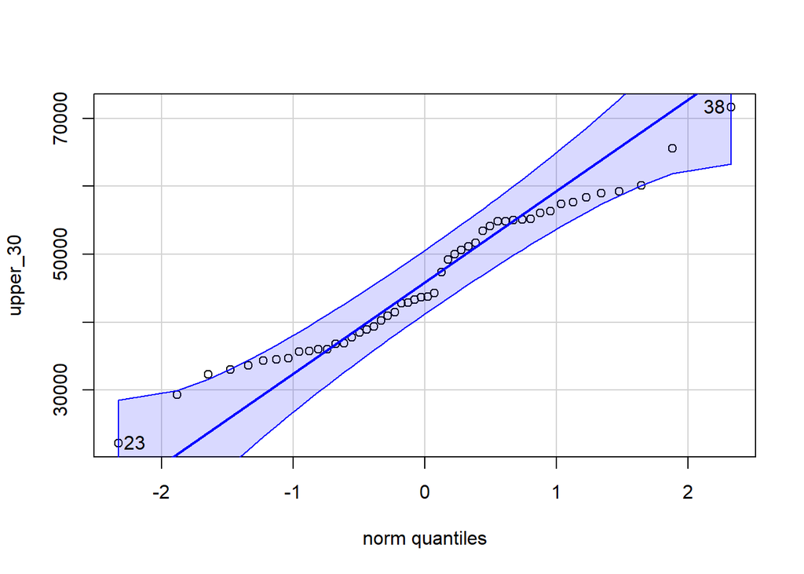

```
[1] 38 23
```

```r
library(car)

car:::qqPlot(upper_30)
```

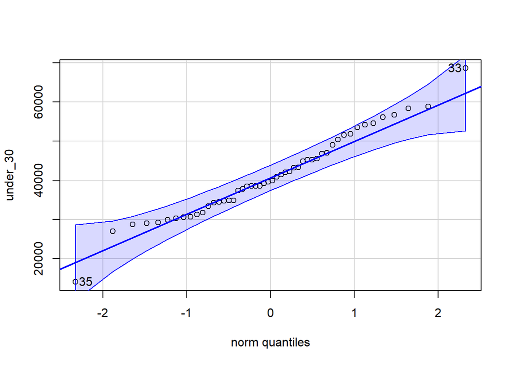

```
[1] 33 35
```

```r
car:::qqPlot(under_30)
```

```r
shapiro.test(upper_30)
```

```
    Shapiro-Wilk normality test

data:  upper_30
W = 0.96657, p-value = 0.1673
```

```r
ks.test(x = jitter(upper_30),
        y = "pnorm",
        mean = mean(upper_30),
        sd = sd(upper_30))
```

```
    Exact one-sample Kolmogorov-Smirnov test

data:  jitter(upper_30)
D = 0.1036, p-value = 0.6192
alternative hypothesis: two-sided
```

```r
library(nortest)
nortest:::lillie.test(upper_30)
```

```
    Lilliefors (Kolmogorov-Smirnov) normality test

data:  upper_30
D = 0.10354, p-value = 0.1987
```

```r
nortest:::ad.test(upper_30)
```

```
    Anderson-Darling normality test

data:  upper_30
A = 0.80719, p-value = 0.03421
```

```r
shapiro.test(under_30)
```

```
    Shapiro-Wilk normality test

data:  under_30
W = 0.97963, p-value = 0.5366
```

```r
ks.test(x = jitter(under_30),
        y = "pnorm",
        mean = mean(under_30),
        sd = sd(under_30))
```

```
    Exact one-sample Kolmogorov-Smirnov test

data:  jitter(under_30)
D = 0.073134, p-value = 0.934
alternative hypothesis: two-sided
```

```r
library(nortest)
nortest:::lillie.test(under_30)
```

```
    Lilliefors (Kolmogorov-Smirnov) normality test

data:  under_30
D = 0.073247, p-value = 0.7217
```

```r
nortest:::ad.test(under_30)
```

```
    Anderson-Darling normality test

data:  under_30
A = 0.37747, p-value = 0.3961
```

### 2.1.2 Check variance homogeneity | Kiểm tra giả thuyết phương sai đồng nhất

H0: phương sai giữa các nhóm bằng nhau

H1: có ít nhất một nhóm có phương sai khác biệt

```r
# kiểm định giữa 2 nhóm
# phổ biến nhất, không yêu cầu 2 vector bằng nhau
stats:::var.test(upper_30,
                 under_30)
```

```
    F test to compare two variances

data:  upper_30 and under_30
F = 1.0588, num df = 49, denom df = 49, p-value = 0.8424
alternative hypothesis: true ratio of variances is not equal to 1
95 percent confidence interval:
 0.6008322 1.8657694
sample estimates:
ratio of variances
           1.05878
```

```r
stats:::var.test(salary ~ age_group,
                 data = df_sample)
```

```
    F test to compare two variances

data:  salary by age_group
F = 0.94448, num df = 49, denom df = 49, p-value = 0.8424
alternative hypothesis: true ratio of variances is not equal to 1
95 percent confidence interval:
 0.5359719 1.6643581
sample estimates:
ratio of variances
         0.9444835
```

```r
# kiểm định giữa 2 hay nhiều nhóm
# mạnh khi dữ liệu có phân phối chuẩn
# nhạy với vi phạm giả định chuẩn
stats:::bartlett.test(df_sample$salary, # vector numeric
                      df_sample$age_group) # vector categorical
```

```
    Bartlett test of homogeneity of variances

data:  df_sample$salary and df_sample$age_group
Bartlett's K-squared = 0.039555, df = 1, p-value = 0.8424
```

```r
# kiểm định giữa 2 hay nhiều nhóm
# phù hợp khi dữ liệu chuẩn và không chuẩn
library(car)
# dữ liệu phân bố chuẩn
car::leveneTest(df_sample$salary,
                df_sample$age_group,
                center = "mean")
```

```
Levene's Test for Homogeneity of Variance (center = "mean")
      Df F value Pr(>F)
group  1  0.7997 0.3734
      98
```

```r
# dữ liệu lệch chuẩn Brown–Forsythe test (biến thể của Levene's test)
car::leveneTest(df_sample$salary,
                df_sample$age_group,
                center = "median")
```

```
Levene's Test for Homogeneity of Variance (center = "median")
      Df F value Pr(>F)
group  1  0.5789 0.4486
      98
```

```r
# kiểm định giữa 2 hay nhiều nhóm
# khi dữ liệu không có phân bố chuẩn
# Performs a Fligner-Killeen (median) test of the null that the variances in each of the groups (samples) are the same.
stats::fligner.test(df_sample$salary,
                   df_sample$major)
```

```
    Fligner-Killeen test of homogeneity of variances

data:  df_sample$salary and df_sample$major
Fligner-Killeen:med chi-squared = 16.767, df = 5, p-value = 0.004964
```

### 2.1.3 Vẽ đồ thị boxplot

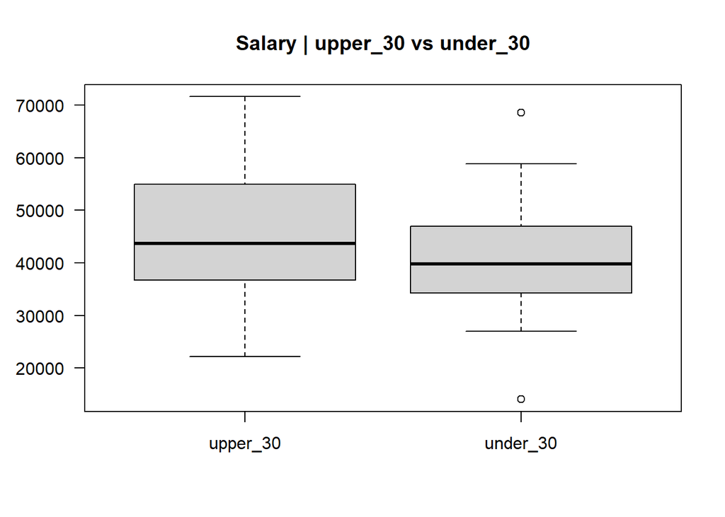

```r
boxplot(upper_30, under_30,
        las = 1,
        names = c("upper_30", "under_30"),
        main = "Salary | upper_30 vs under_30")
```

### 2.1.4 Kiểm định two-sample t-test

#### 2.1.4.1 Dữ liệu phân bố chuẩn và phương sai đồng nhất

NORMALITY | VARIANCE HOMOGENEITY (EQUAL VARIANCE)

```r
# TWO-TAILS
# H0: trung binh upper_30 = trung binh under_30
# H1: trung binh upper_30 ≠ trung binh under_30

t.test(upper_30,
       under_30,
       var.equal = TRUE,
       paired = FALSE,
       alternative = "two.sided")
```

```
    Two Sample t-test

data:  upper_30 and under_30
t = 2.2423, df = 98, p-value = 0.0272
alternative hypothesis: true difference in means is not equal to 0
95 percent confidence interval:
  538.9874 8836.1662
sample estimates:
mean of x mean of y
 45855.14  41167.57
```

```r
# LEFT-TAIL
# H0: trung binh upper_30 ≥ trung binh under_30
# H1: trung binh upper_30 < trung binh under_30

t.test(upper_30,
       under_30,
       var.equal = TRUE,
       paired = FALSE,
       alternative = "less")
```

```
    Two Sample t-test

data:  upper_30 and under_30
t = 2.2423, df = 98, p-value = 0.9864
alternative hypothesis: true difference in means is less than 0
95 percent confidence interval:
     -Inf 8159.009
sample estimates:
mean of x mean of y
 45855.14  41167.57
```

```r
# RIGHT-TAIL
# H0: trung binh upper_30 ≤ trung binh under_30
# H1: trung binh upper_30 > trung binh under_30

t.test(upper_30,
       under_30,
       var.equal = TRUE,
       paired = FALSE,
       alternative = "greater")
```

```
    Two Sample t-test

data:  upper_30 and under_30
t = 2.2423, df = 98, p-value = 0.0136
alternative hypothesis: true difference in means is greater than 0
95 percent confidence interval:
 1216.144      Inf
sample estimates:
mean of x mean of y
 45855.14  41167.57
```

#### 2.1.4.2 Dữ liệu phân bố chuẩn và phương sai không đồng nhất

NORMALITY and VARIANCE HETEROSKEDASTICITY (UNEQUAL VARIANCE)

Sử dụng t-test cải tiến | Welch Two Sample t-test

```r
t.test(upper_30,
       under_30,
       var.equal = FALSE,
       paired = FALSE,
       alternative = "two.sided")
```

```
    Welch Two Sample t-test

data:  upper_30 and under_30
t = 2.2423, df = 97.92, p-value = 0.0272
alternative hypothesis: true difference in means is not equal to 0
95 percent confidence interval:
  538.9451 8836.2085
sample estimates:
mean of x mean of y
 45855.14  41167.57
```

#### 2.1.4.3 Effect size

Compute the effect size for t-test. T-test conventional effect sizes, proposed by Cohen, are: 0.2 (small effect), 0.5 (moderate effect) and 0.8 (large effect).

```r
library(rstatix)
rstatix:::cohens_d(salary ~ age_group,
                      data = df_sample,
                   var.equal = FALSE,
                   paired = FALSE)
```

```
# A tibble: 1 × 7
  .y.    group1 group2 effsize    n1    n2 magnitude
* <chr>  <chr>  <chr>    <dbl> <int> <int> <ord>
1 salary < 30   >= 30   -0.448    50    50 small
```

```r
library(effectsize)

effectsize:::cohens_d(
  upper_30,
  under_30,
  paired = F
)
```

```
Cohen's d |       95% CI
------------------------
0.45      | [0.05, 0.84]

- Estimated using pooled SD.
```

## 2.2 Nonparametric

### 2.2.1 Independent two-sample Mann–Whitney U test

Mann–Whitney U test (aka Wilcoxon Rank Sum test) compares two independent groups. Dành cho dữ liệu không đạt phân phối chuẩn (gần chuẩn).

Nonparametric không yêu cầu giả định NORMALITY và VARIANCE HOMOGENEITY.

```r
wilcox.test(upper_30,
       under_30,
       paired = FALSE,
       alternative = "two.sided")
```

```
    Wilcoxon rank sum test with continuity correction

data:  upper_30 and under_30
W = 1563, p-value = 0.03122
alternative hypothesis: true location shift is not equal to 0
```

```r
library(rstatix)
# nếu chỉ có so sánh giữa 2 nhóm thì không cần adjust p-value
rstatix:::wilcox_test(salary ~ age_group,
                      data = df_sample,
                      paired = FALSE,
                      p.adjust.method = "none",
                      alternative = "two.sided")
```

```
# A tibble: 1 × 7
  .y.    group1 group2    n1    n2 statistic      p
* <chr>  <chr>  <chr>  <int> <int>     <dbl>  <dbl>
1 salary < 30   >= 30     50    50       937 0.0312
```

### 2.2.2 Effect size

The r value varies from 0 to close to 1. The interpretation values for r commonly in published litterature and on the internet are: 0.10 - < 0.3 (small effect), 0.30 - < 0.5 (moderate effect) and >= 0.5 (large effect).

```r
rstatix:::wilcox_effsize(salary ~ age_group,
                      data = df_sample,
                      paired = FALSE)
```

```
# A tibble: 1 × 7
  .y.    group1 group2 effsize    n1    n2 magnitude
* <chr>  <chr>  <chr>    <dbl> <int> <int> <ord>
1 salary < 30   >= 30    0.216    50    50 small
```

### 2.2.3 Independent two-sample Mood’s Median Test

Performs a Mood’s median test to compare medians of independent samples

```r
# https://rcompanion.org/handbook/F_09.html
library(RVAideMemoire)
RVAideMemoire:::mood.medtest(salary ~ age_group,
                      data = df_sample,
                      exact = FALSE)
```

```
    Mood's median test

data:  salary by age_group
X-squared = 1.96, df = 1, p-value = 0.1615
```

Testing the equality of the distributions of a numeric response variable in two or more independent groups against shift alternatives.

```r
library(coin)

coin:::median_test(salary ~ age_group,
                      data = df_sample)
```

```
    Asymptotic Two-Sample Brown-Mood Median Test

data:  salary by age_group (< 30, >= 30)
Z = -1.592, p-value = 0.1114
alternative hypothesis: true mu is not equal to 0
```

## 2.3 Áp dụng package

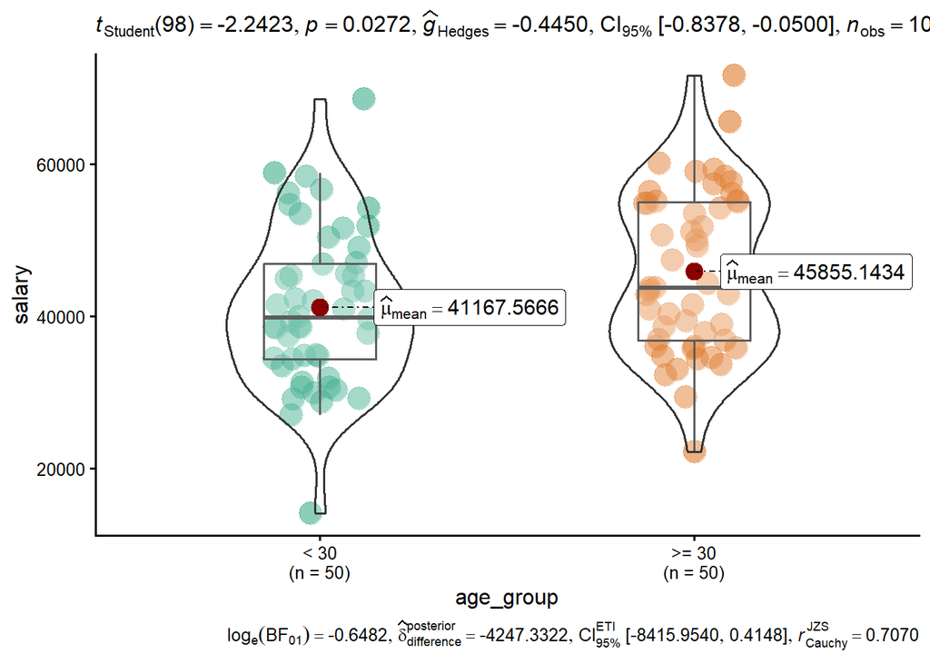

```r
library(ggstatsplot)
library(tidyverse)

set.seed(20)

ggstatsplot:::ggbetweenstats(data = df_sample,
                     x = age_group,
                     y = salary,
                     type = "parametric",
                     var.equal = TRUE,
                     plot.type = "box",
                     pairwise.comparisons = T,
                     pairwise.display = "all",
                     p.adjust.method = "none",
                     centrality.plotting = T,
                     centrality.path = T,
                     digits = 4L,
                       centrality.point.args = list(size = 4, color = "darkred"),
                     centrality.label.args = list(size = 4,
                                                  nudge_x = 0.4,
                                                  segment.linetype = 4),
                     ggtheme = theme_classic(base_size = 12),
                     bf.message = T,
                     results.subtitle = T,
                     caption = "",
                     ggsignif.args = list(size = 0.5,
                                          vjust = 0,
                                          step_increase = 0.1,
                                          textsize = 5),
                     point.args = list(position = ggplot2::position_jitterdodge(dodge.width = 0.6),
                                       alpha = 0.5,
                                       size = 6,
                                       stroke = 0,
                                       na.rm = TRUE)
                     )
```

```r
library(dabestr)

two_groups_unpaired <- dabestr:::load(df_sample,
  x = age_group, y = salary,
  paired = NULL,
  idx = c("< 30", ">= 30")
)

two_groups_unpaired.mean_diff <-  dabestr::cohens_d(two_groups_unpaired)


print(two_groups_unpaired.mean_diff)
```

```
DABESTR v2025.3.15
==================

Good evening!
The current time is 19:59 PM on Friday October 30, 2026.

The character(0) Cohen's d between >= 30 and < 30 is 0.448 [95%CI 0.054, 0.851].
The p-value of the two-sided permutation t-test is 0.0272, calculated for legacy purposes only.

5000 bootstrap samples were taken; the confidence interval is bias-corrected and accelerated.
Any p-value reported is the probability of observing the effect size (or greater),
assuming the null hypothesis of zero difference is true.
For each p-value, 5000 reshuffles of the control and test labels were performed.
```

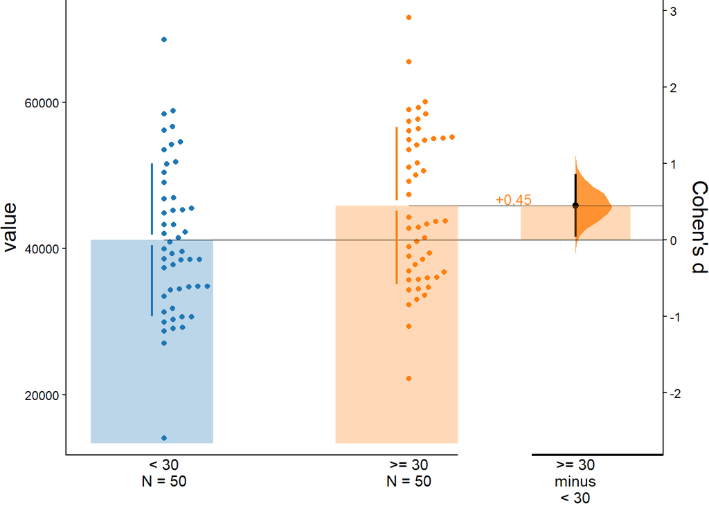

```r
dabest_plot(two_groups_unpaired.mean_diff)
```

`https://rpubs.com/lengockhanhi/454078`

# 3 Dependent two sample

## 3.1 Parametric paired t-test

```r
t.test(df_sample$score1,
       df_sample$score2,
       var.equal = TRUE,
       paired = TRUE,
       alternative = "two.sided")
```

```
    Paired t-test

data:  df_sample$score1 and df_sample$score2
t = -1.2863, df = 99, p-value = 0.2014
alternative hypothesis: true mean difference is not equal to 0
95 percent confidence interval:
 -2.2629386  0.4829386
sample estimates:
mean difference
          -0.89
```

```r
t.test(df_sample$score1 - df_sample$score2,
       mu = 0,
       alternative = "two.sided")
```

```
    One Sample t-test

data:  df_sample$score1 - df_sample$score2
t = -1.2863, df = 99, p-value = 0.2014
alternative hypothesis: true mean is not equal to 0
95 percent confidence interval:
 -2.2629386  0.4829386
sample estimates:
mean of x
    -0.89
```

```r
# head(df_sample)

df_score <- df_sample[ , c("stud.id", "score1", "score2")]
df_score
```

```
    stud.id score1 score2
1    127329     71     73
2    699675     69     59
3    373120     56     52
4    645027     60     48
5    887121     81     73
6    263680     74     64
7    644535     90     85
8    920111     85     88
9    534172     68     73
10   152383     54     45
11   165588     67     77
12   358961     93     90
13   854188     71     63
14   355955     50     59
```

[output cut: 86 more lines]

```r
###
df_score1 <-  df_sample[ , c("stud.id", "score1")]

names(df_score1) <- c("id", "score")

df_score1$group <- "hk1"

# df_score1

###
df_score2 <-  df_sample[ , c("stud.id", "score2")]

names(df_score2) <- c("id", "score")

df_score2$group <- "hk2"

# df_score2

df_long <- rbind(df_score1,
                 df_score2)

df_long
```

```
        id score group
1   127329    71   hk1
2   699675    69   hk1
3   373120    56   hk1
4   645027    60   hk1
5   887121    81   hk1
6   263680    74   hk1
7   644535    90   hk1
8   920111    85   hk1
9   534172    68   hk1
10  152383    54   hk1
11  165588    67   hk1
12  358961    93   hk1
13  854188    71   hk1
14  355955    50   hk1
```

[output cut: 186 more lines]

```r
p1 <- ggstatsplot:::ggwithinstats(data = df_long,
                     x = group,
                     y = score,
                     type = "parametric",
                     var.equal = TRUE,
                     plot.type = "box",
                     pairwise.comparisons = T,
                     pairwise.display = "all",
                     p.adjust.method = "none",
                     centrality.plotting = T,
                     centrality.path = T,
                     digits = 4L,
                     ggtheme = theme_classic(base_size = 12),
                     bf.message = T,
                     results.subtitle = T,
                     caption = "",
                     centrality.point.args = list(size = 4, color = "darkred"),
                     centrality.label.args = list(size = 4,
                                                  nudge_x = 0.4,
                                                  segment.linetype = 4),
                     ggsignif.args = list(size = 0.5,
                                          vjust = 0,
                                          step_increase = 0.1,
                                          textsize = 5),
                     point.path.args = list(alpha = 0.5,
                                            lwd = 0.8,
                                            linetype = "solid",
                                            color = "blue"),
                     point.args = list(position = ggplot2::position_jitterdodge(dodge.width = 0,                                                                 jitter.width = 0,                                                                jitter.height = 0),
                                       alpha = 0.5,
                                       size = 6,
                                       stroke = 0,
                                       na.rm = TRUE)
                     )

ggsave(filename = "p1_paired.png",
       width = 8,
       height = 6,
       plot = p1,
       dpi = 300,
       units = "in")
```

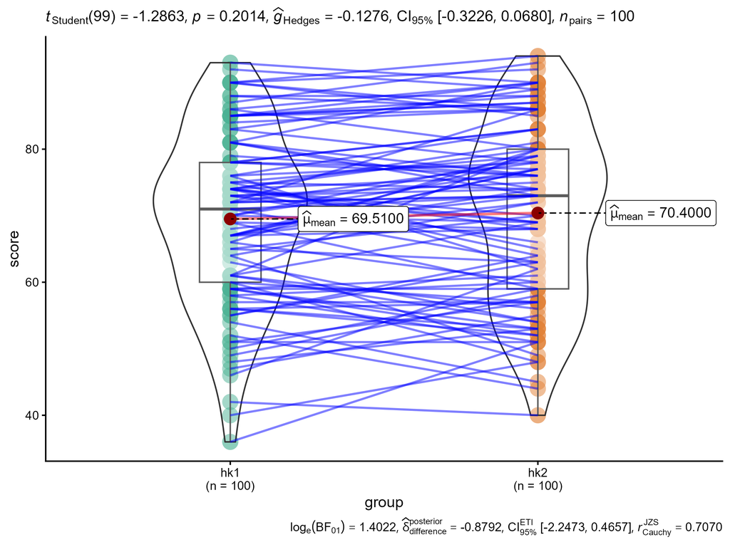

```r
library(dabestr)

two_groups_paired <- dabestr:::load(df_long,
  x = group,
  y = score,
  paired = "sequential",
  idx = c("hk1", "hk2"),
  id_col = id
)

two_groups_paired.mean_diff <-  dabestr:::mean_diff(two_groups_paired)

print(two_groups_paired.mean_diff)
```

[output not shown]

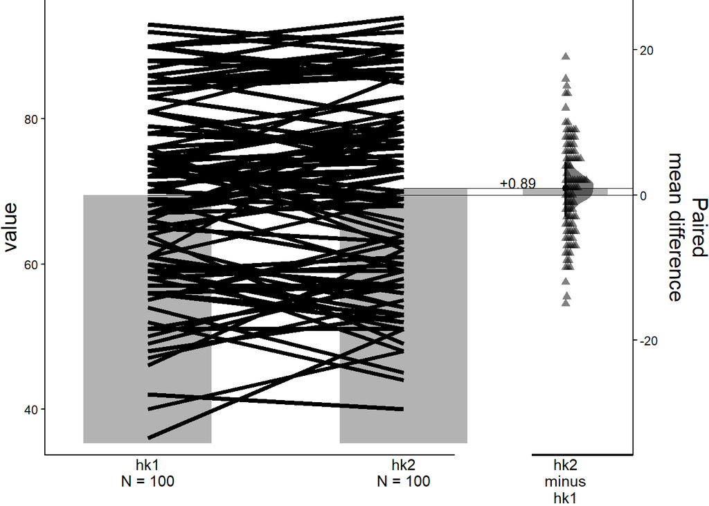

```r
dabest_plot(two_groups_paired.mean_diff)
```

```r
library(rstatix)
rstatix:::cohens_d(salary ~ age_group,
                      data = df_sample,
                   var.equal = T,
                   paired = T)
```

```
# A tibble: 1 × 7
  .y.    group1 group2 effsize    n1    n2 magnitude
* <chr>  <chr>  <chr>    <dbl> <int> <int> <ord>
1 salary < 30   >= 30   -0.310    50    50 small
```

```r
library(effectsize)

effectsize:::cohens_d(
  upper_30,
  under_30,
  paired = T
)
```

```
Cohen's d |       95% CI
------------------------
0.31      | [0.02, 0.59]
```

## 3.2 Nonparametric | Paired

### 3.2.1 Wilcoxon Signed Rank test

```r
wilcox.test(upper_30,
       under_30,
       paired = T,
       alternative = "two.sided")
```

```
    Wilcoxon signed rank test with continuity correction

data:  upper_30 and under_30
V = 858, p-value = 0.03369
alternative hypothesis: true location shift is not equal to 0
```

### 3.2.2 Sign test for paired samples

Khi phân phối lệch chuẩn quá nhiều thì ta dùng sign test.

```r
library(BSDA)
BSDA:::SIGN.test(upper_30,
                 under_30,
                 md = 0,
                 alternative = "two.sided",
                 conf.level = 0.95)
```

```
    Dependent-samples Sign-Test

data:  upper_30 and under_30
S = 33, p-value = 0.03284
alternative hypothesis: true median difference is not equal to 0
95 percent confidence interval:
  803.5553 9798.7770
sample estimates:
median of x-y
     4115.385

Achieved and Interpolated Confidence Intervals:

                  Conf.Level   L.E.pt   U.E.pt
Lower Achieved CI     0.9351 955.7794 9699.373
Interpolated CI       0.9500 803.5553 9798.777
Upper Achieved CI     0.9672 628.3350 9913.197
```

```r
library(DescTools)
DescTools:::SignTest(upper_30,
                     under_30,
                     md = 0,
                     alternative = "two.sided",
                     conf.level = 0.95)
```

```
    Dependent-samples Sign-Test

data:  upper_30 and under_30
S = 33, number of differences = 50, p-value = 0.03284
alternative hypothesis: true median difference is not equal to 0
96.7 percent confidence interval:
  628.335 9913.197
sample estimates:
median of the differences
                 4115.385
```

# 4 t-test cho nhiều nhóm

```r
library(ggplot2)
library(ggsignif)

options(scipen = 999)

dp <- df[ , c("gender",
              "major",
              "salary")]
dim(dp)
```

```
[1] 1753    3
```

```r
dp <- na.omit(dp)
dim(dp)
```

```
[1] 1753    3
```

```r
p1 <- ggplot(data = dp,
       mapping = aes(x = gender,
                     y = salary,
                     fill = gender)) +

  # geom_boxplot() +

   geom_violin(alpha = 0.1,
              show.legend = F) +

  geom_point(position = position_jitter(width = 0.1, height = 0),
             mapping = aes(color = gender),
             alpha = 0.5) +

    stat_summary(fun.data = mean_cl_boot,
               geom ='crossbar',
               width = 0.6,
               alpha = 0.5,
               aes(fill = gender)) +

   ggsignif:::geom_signif(comparisons =  list(c("Male", "Female")),
                         map_signif_level = function(p_ok) {
                           options(scipen = 1)
                           options(digits = 2)
                          capture.output(cat(p_ok)) -> p_ok_final
                         paste0("p", " = ", p_ok_final)

                         },
                         textsize = 4,
                         vjust = -0.5,
                         step_increase = 0.6,
                         test = "t.test",
                         test.args = list(paired = F)
                         ) +

  facet_grid(~ major) +

  scale_y_continuous(limits = c(10000,100000),
                     breaks = seq(from = 10000,
                                  to = 100000,
                                  by = 10000)) +

  theme_bw(base_size = 13) +

  labs(x = "")

# p1

ggsave(filename = "p1.png",
       plot = p1,
       width = 16,
       height = 4,
       units = "in",
       dpi = 300)
```

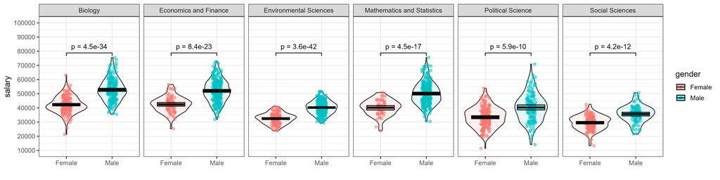

# 5 ANOVA 1 yếu tố | Parametric | Không bắt cặp

## 5.1 Check assumption

### 5.1.1 Normality

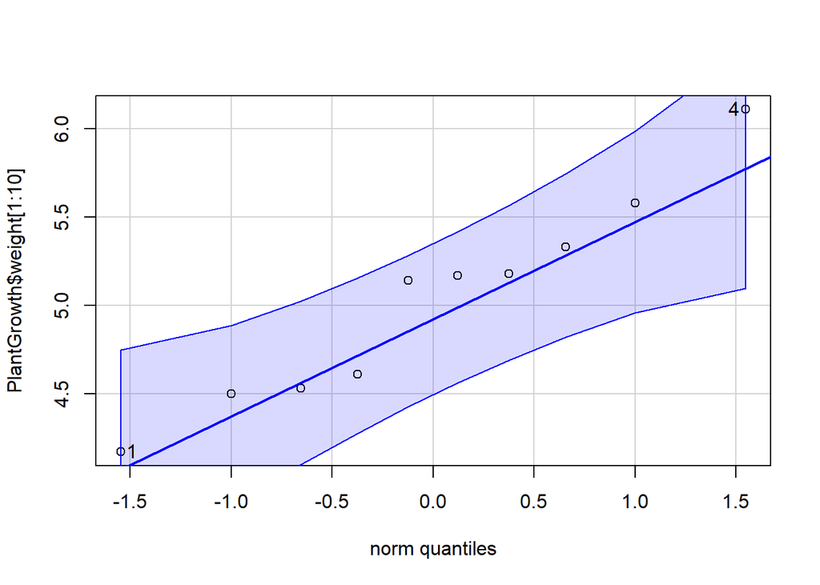

```
[1] 4 1
```

```r
library(ggplot2)
library(ggpubr)

car:::qqPlot(PlantGrowth$weight[1:10])
```

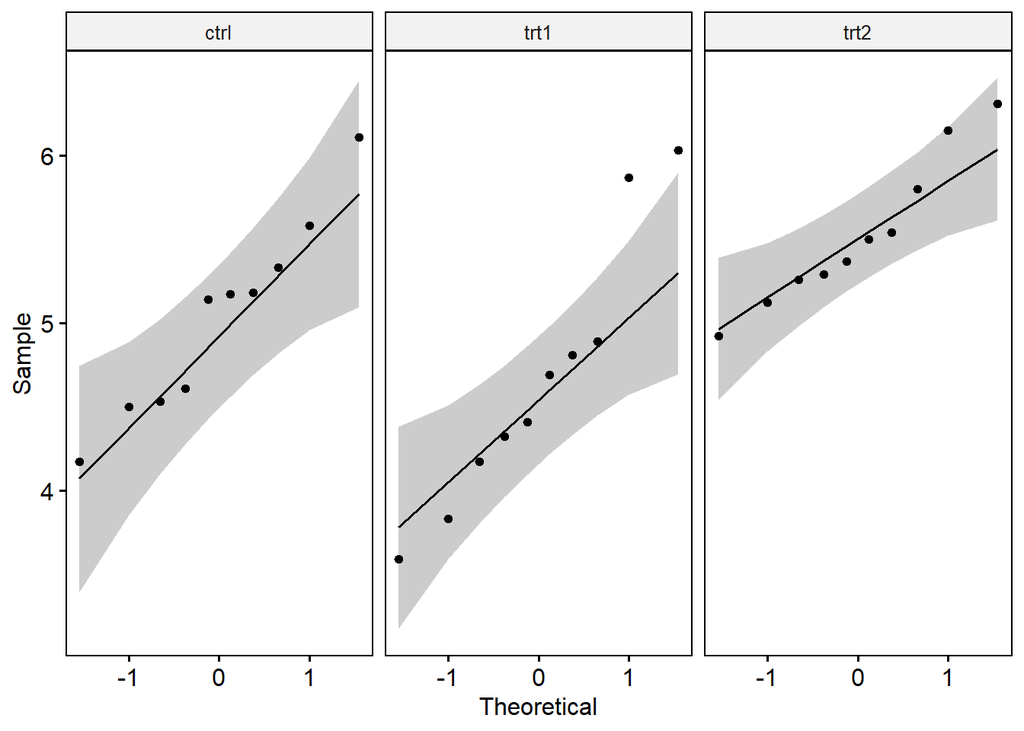

```r
ggpubr:::ggqqplot(data = PlantGrowth,
                  x = "weight",
                  facet.by = "group")
```

```r
ctrl <- PlantGrowth$weight[1:10]

shapiro.test(ctrl)
```

```
    Shapiro-Wilk normality test

data:  ctrl
W = 1, p-value = 0.7
```

```r
ks.test(x = jitter(ctrl),
        y = "pnorm",
        mean = mean(ctrl),
        sd = sd(ctrl))
```

```
    Exact one-sample Kolmogorov-Smirnov test

data:  jitter(ctrl)
D = 0.2, p-value = 0.9
alternative hypothesis: two-sided
```

```r
library(nortest)
nortest:::lillie.test(ctrl)
```

```
    Lilliefors (Kolmogorov-Smirnov) normality test

data:  ctrl
D = 0.2, p-value = 0.5
```

```r
nortest:::ad.test(ctrl)
```

```
    Anderson-Darling normality test

data:  ctrl
A = 0.3, p-value = 0.6
```

```r
trt1 <- PlantGrowth$weight[11:20]

shapiro.test(trt1)
```

```
    Shapiro-Wilk normality test

data:  trt1
W = 0.9, p-value = 0.5
```

```r
ks.test(x = jitter(trt1),
        y = "pnorm",
        mean = mean(trt1),
        sd = sd(trt1))
```

```
    Exact one-sample Kolmogorov-Smirnov test

data:  jitter(trt1)
D = 0.2, p-value = 0.8
alternative hypothesis: two-sided
```

```r
library(nortest)
nortest:::lillie.test(trt1)
```

```
    Lilliefors (Kolmogorov-Smirnov) normality test

data:  trt1
D = 0.2, p-value = 0.4
```

```r
nortest:::ad.test(trt1)
```

```
    Anderson-Darling normality test

data:  trt1
A = 0.3, p-value = 0.4
```

```r
library(tidyr)
library(dplyr)

# reshape tu long qua wide
PlantGrowth_wide <- PlantGrowth %>%
  group_by(group) %>%
  mutate(id = row_number()) %>%
  ungroup() %>% as.data.frame() %>%
  pivot_wider(
    names_from = group,
    values_from = weight
  )

PlantGrowth_wide  <- PlantGrowth_wide[, -1]

library(MVN)

MVN:::mvn(PlantGrowth_wide)
```

```
$multivariate_normality
           Test Statistic p.value     Method      MVN
1 Henze-Zirkler       0.5    0.44 asymptotic ✓ Normal

$univariate_normality
              Test Variable Statistic p.value Normality
1 Anderson-Darling     ctrl      0.28    0.56  ✓ Normal
2 Anderson-Darling     trt1      0.33    0.44  ✓ Normal
3 Anderson-Darling     trt2      0.31    0.50  ✓ Normal

$descriptives
  Variable  n Mean Std.Dev Median Min Max 25th 75th Skew Kurtosis
1     ctrl 10  5.0    0.58    5.2 4.2 6.1  4.5  5.3 0.27      2.3
2     trt1 10  4.7    0.79    4.5 3.6 6.0  4.2  4.9 0.56      2.3
3     trt2 10  5.5    0.44    5.4 4.9 6.3  5.3  5.7 0.57      2.3

$data
# A tibble: 10 × 3
    ctrl  trt1  trt2
   <dbl> <dbl> <dbl>
 1  4.17  4.81  6.31
 2  5.58  4.17  5.12
 3  5.18  4.41  5.54
 4  6.11  3.59  5.5
 5  4.5   5.87  5.37
 6  4.61  3.83  5.29
 7  5.17  6.03  4.92
 8  4.53  4.89  6.15
 9  5.33  4.32  5.8
10  5.14  4.69  5.26

$subset
NULL

$outlierMethod
[1] "none"

attr(,"class")
[1] "mvn"
```

### 5.1.2 Variance homogeneity

```r
library(car)

car:::leveneTest(weight ~ group,
           data = PlantGrowth)
```

```
Levene's Test for Homogeneity of Variance (center = median)
      Df F value Pr(>F)
group  2    1.12   0.34
      27
```

```r
stats:::bartlett.test(weight ~ group,
                      data = PlantGrowth)
```

```
    Bartlett test of homogeneity of variances

data:  weight by group
Bartlett's K-squared = 3, df = 2, p-value = 0.2
```

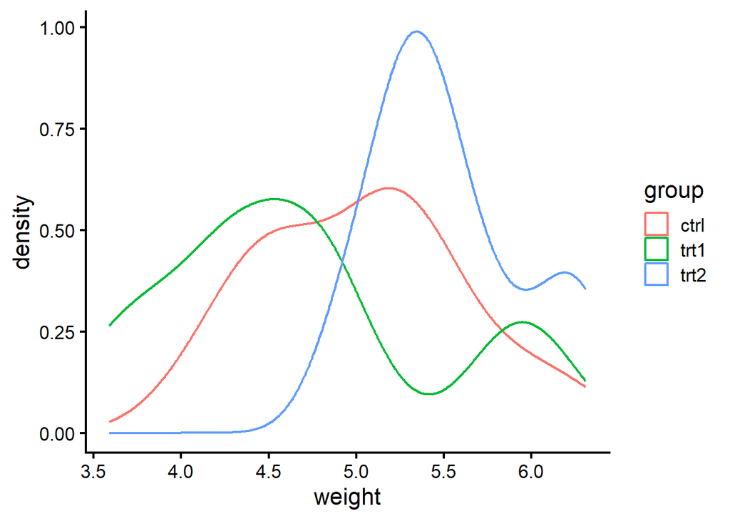

```r
library(ggplot2)

ggplot(data = PlantGrowth,
       mapping = aes(x = weight,
                     colour = group)) +
  geom_density() +

  theme_classic(base_size = 16)
```

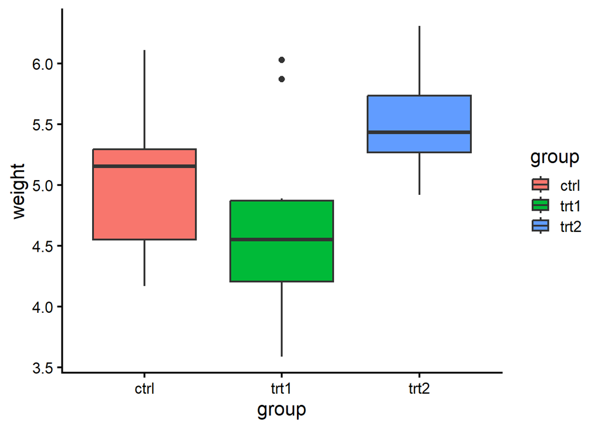

```r
ggplot(data = PlantGrowth,
       mapping = aes(x = group,
                     y = weight,
                     fill = group)) +
  geom_boxplot() +

  theme_classic(base_size = 16)
```

## 5.2 Run ANOVA one-way

```r
# ANOVA type I | variance equal
fit1 <- aov(weight ~ group,
           data = PlantGrowth)

summary(fit1)
```

```
            Df Sum Sq Mean Sq F value Pr(>F)
group        2   3.77   1.883    4.85  0.016 *
Residuals   27  10.49   0.389
---
Signif. codes:  0 '***' 0.001 '**' 0.01 '*' 0.05 '.' 0.1 ' ' 1
```

```r
fit2 <- stats:::oneway.test(weight ~ group,
                            data = PlantGrowth,
                            var.equal = T)

fit2
```

```
    One-way analysis of means

data:  weight and group
F = 5, num df = 2, denom df = 27, p-value = 0.02
```

```r
# ANOVA type I | variance unequal Welch's ANOVA
fit3 <- stats:::oneway.test(weight ~ group,
                            data = PlantGrowth,
                            var.equal = F)

fit3
```

```
    One-way analysis of means (not assuming equal variances)

data:  weight and group
F = 5, num df = 2, denom df = 17, p-value = 0.02
```

```r
library(car)

# ANOVA type II
car:::Anova(fit1,
            type = "II")
```

```
Anova Table (Type II tests)

Response: weight
          Sum Sq Df F value Pr(>F)
group       3.77  2    4.85  0.016 *
Residuals  10.49 27
---
Signif. codes:  0 '***' 0.001 '**' 0.01 '*' 0.05 '.' 0.1 ' ' 1
```

```r
# ANOVA type III
car:::Anova(fit1, type = "III")
```

```
Anova Table (Type III tests)

Response: weight
            Sum Sq Df F value Pr(>F)
(Intercept)  253.2  1  651.60 <2e-16 ***
group          3.8  2    4.85  0.016 *
Residuals     10.5 27
---
Signif. codes:  0 '***' 0.001 '**' 0.01 '*' 0.05 '.' 0.1 ' ' 1
```

## 5.3 Effect size

```r
library(effectsize)

# Eta-squared
effectsize:::eta_squared(fit1)
```

```
# Effect Size for ANOVA

Parameter | Eta2 |       95% CI
-------------------------------
group     | 0.26 | [0.04, 1.00]

- One-sided CIs: upper bound fixed at [1.00].
```

```r
# eta-squared
# Tỷ lệ phương sai của weight được giải thích bởi group.
# 0.01  Nhỏ
# 0.06  Trung bình
# 0.14  Lớn
```

```r
# Omega-squared
# Ước lượng effect size ít thiên lệch hơn trong quần thể.
effectsize:::omega_squared(fit1)
```

```
# Effect Size for ANOVA

Parameter | Omega2 |       95% CI
---------------------------------
group     |   0.20 | [0.00, 1.00]

- One-sided CIs: upper bound fixed at [1.00].
```

```r
# Cohen's f
# Thước đo effect size dựa trên độ lớn khác biệt giữa các trung bình nhóm.
effectsize:::cohens_f(fit1)
```

```
# Effect Size for ANOVA

Parameter | Cohen's f |      95% CI
-----------------------------------
group     |      0.60 | [0.19, Inf]

- One-sided CIs: upper bound fixed at [Inf].
```

```r
library(rstatix)

# Eta-squared
rstatix:::anova_test(
  data = PlantGrowth,
  dv = weight,
  effect.size = "pes",
  between = group)
```

```
ANOVA Table (type II tests)

  Effect DFn DFd   F     p p<.05  pes
1  group   2  27 4.8 0.016     * 0.26
```

## 5.4 Post-hoc analysis | Multiple comparisons

### 5.4.1 Tukey

```r
TukeyHSD(fit1)
```

```
  Tukey multiple comparisons of means
    95% family-wise confidence level

Fit: aov(formula = weight ~ group, data = PlantGrowth)

$group
           diff   lwr  upr p adj
trt1-ctrl -0.37 -1.06 0.32  0.39
trt2-ctrl  0.49 -0.20 1.19  0.20
trt2-trt1  0.87  0.17 1.56  0.01
```

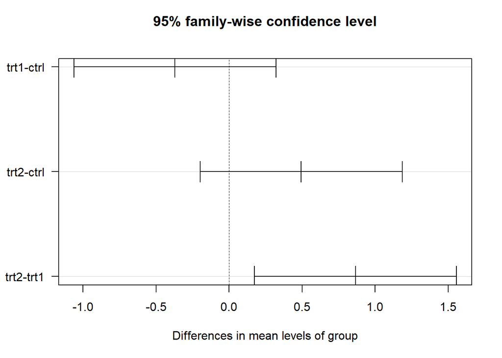

```r
plot(TukeyHSD(fit1),
     las = 1)
```

```r
library(agricolae)

agricolae:::HSD.test(fit1,
                     trt = "group",
                     console = TRUE)
```

```
Study: fit1 ~ "group"

HSD Test for weight

Mean Square Error:  0.39

group,  means

     weight  std  r  se Min Max Q25 Q50 Q75
ctrl    5.0 0.58 10 0.2 4.2 6.1 4.5 5.2 5.3
trt1    4.7 0.79 10 0.2 3.6 6.0 4.2 4.6 4.9
trt2    5.5 0.44 10 0.2 4.9 6.3 5.3 5.4 5.7

Alpha: 0.05 ; DF Error: 27
Critical Value of Studentized Range: 3.5

Minimun Significant Difference: 0.69

Treatments with the same letter are not significantly different.

     weight groups
trt2    5.5      a
ctrl    5.0     ab
trt1    4.7      b
```

### 5.4.2 Bonferroni

• “bonferroni” Kiểm soát family-wise error rate (FWER), khá bảo thủ

• “holm” Kiểm soát FWER, thường ít bảo thủ hơn Bonferroni

• “BH” Kiểm soát false discovery rate (FDR)

```r
pairwise.t.test(
  x = PlantGrowth$weight,
  g = PlantGrowth$group,
  p.adjust.method = "bonferroni",
  paired = FALSE,
  pool.sd = TRUE
)
```

```
    Pairwise comparisons using t tests with pooled SD

data:  PlantGrowth$weight and PlantGrowth$group

     ctrl trt1
trt1 0.58 -
trt2 0.26 0.01

P value adjustment method: bonferroni
```

```r
pairwise.t.test(
  x = PlantGrowth$weight,
  g = PlantGrowth$group,
  p.adjust.method = "BH",
  paired = FALSE,
  pool.sd = TRUE
)
```

```
    Pairwise comparisons using t tests with pooled SD

data:  PlantGrowth$weight and PlantGrowth$group

     ctrl trt1
trt1 0.19 -
trt2 0.13 0.01

P value adjustment method: BH
```

```r
pairwise.t.test(
  x = PlantGrowth$weight,
  g = PlantGrowth$group,
  p.adjust.method = "holm",
  paired = FALSE,
  pool.sd = TRUE
)
```

```
    Pairwise comparisons using t tests with pooled SD

data:  PlantGrowth$weight and PlantGrowth$group

     ctrl trt1
trt1 0.19 -
trt2 0.18 0.01

P value adjustment method: holm
```

```r
pairwise.t.test(
  x = PlantGrowth$weight,
  g = PlantGrowth$group,
  p.adjust.method = "bonferroni",
  paired = FALSE,
  pool.sd = FALSE
)
```

```
    Pairwise comparisons using t tests with non-pooled SD

data:  PlantGrowth$weight and PlantGrowth$group

     ctrl trt1
trt1 0.75 -
trt2 0.14 0.03

P value adjustment method: bonferroni
```

## 5.5 Vẽ đồ thị

```r
library(ggstatsplot)
library(tidyverse)

set.seed(20)

kq <- ggstatsplot:::ggbetweenstats(data = PlantGrowth,
                     x = group,
                     y = weight,
                     var.equal = TRUE,
                     type = "parametric",
                     plot.type = "box",
                     pairwise.comparisons = T,
                     pairwise.display = "all",
                     p.adjust.method = "bonferroni",
                     # p.adjust.method = "none",
                     centrality.plotting = T,
                     centrality.path = T,
                     digits = 4L,
                     centrality.point.args = list(size = 4, color = "darkred"),
                     centrality.label.args = list(size = 4,
                                                  nudge_x = 0.4,
                                                  segment.linetype = 4),
                     ggtheme = theme_classic(base_size = 12),
                     bf.message = T,
                     results.subtitle = T,
                     caption = "",
                     ggsignif.args = list(size = 0.5,
                                          vjust = 0,
                                          step_increase = 0.1,
                                          textsize = 5),
                     point.args = list(position = ggplot2::position_jitterdodge(dodge.width = 0,                                                                 jitter.width = 0,                                                                jitter.height = 0),
                                       alpha = 0.5,
                                       size = 6,
                                       stroke = 0,
                                       na.rm = TRUE)
                     )  +
  coord_cartesian(ylim = c(3,8))
# kq

ggstatsplot:::extract_stats(kq)
```

```
$subtitle_data
# A tibble: 1 × 14
  statistic    df df.error p.value method                    effectsize estimate conf.level conf.low conf.high conf.method conf.distribution n.obs expression
      <dbl> <dbl>    <dbl>   <dbl> <chr>                     <chr>         <dbl>      <dbl>    <dbl>     <dbl> <chr>       <chr>             <int> <list>
1      4.85     2       27  0.0159 One-way analysis of means Omega2        0.204       0.95  0.00238         1 ncp         F                    30 <language>

$caption_data
# A tibble: 6 × 17
  term          pd prior.distribution prior.location prior.scale  bf10 method                          log_e_bf10 effectsize         estimate std.dev conf.level
  <chr>      <dbl> <chr>                       <dbl>       <dbl> <dbl> <chr>                                <dbl> <chr>                 <dbl>   <dbl>      <dbl>
1 mu         1     cauchy                          0       0.707  3.66 Bayes factors for linear models       1.30 Bayesian R-squared    0.167   0.161       0.95
2 group-ctrl 0.596 cauchy                          0       0.707  3.66 Bayes factors for linear models       1.30 Bayesian R-squared    0.167   0.161       0.95
3 group-trt1 0.985 cauchy                          0       0.707  3.66 Bayes factors for linear models       1.30 Bayesian R-squared    0.167   0.161       0.95
4 group-trt2 0.989 cauchy                          0       0.707  3.66 Bayes factors for linear models       1.30 Bayesian R-squared    0.167   0.161       0.95
5 sig2       1     cauchy                          0       0.707  3.66 Bayes factors for linear models       1.30 Bayesian R-squared    0.167   0.161       0.95
6 g_group    1     cauchy                          0       0.707  3.66 Bayes factors for linear models       1.30 Bayesian R-squared    0.167   0.161       0.95
  conf.low conf.high conf.method n.obs expression
     <dbl>     <dbl> <chr>       <int> <list>
1        0     0.381 HDI            30 <language>
2        0     0.381 HDI            30 <language>
3        0     0.381 HDI            30 <language>
4        0     0.381 HDI            30 <language>
5        0     0.381 HDI            30 <language>
6        0     0.381 HDI            30 <language>

$pairwise_comparisons_data
# A tibble: 3 × 6
  group1 group2 p.value p.adjust.method test        expression
  <chr>  <chr>    <dbl> <chr>           <chr>       <list>
1 ctrl   trt1    0.583  Bonferroni      Student's t <language>
2 ctrl   trt2    0.263  Bonferroni      Student's t <language>
3 trt1   trt2    0.0134 Bonferroni      Student's t <language>

$descriptive_data
NULL

$one_sample_data
NULL

$tidy_data
NULL

$glance_data
NULL

attr(,"class")
[1] "ggstatsplot_stats" "list"
```

```r
ggsave(filename = "kq.png",
       plot = kq,
       width = 8,
       height = 6,
       units = "in",
       dpi = 300)
```

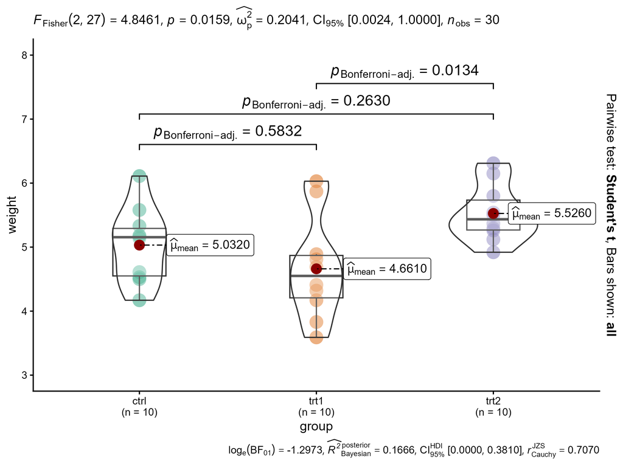

## 5.6 Estimated marginal means

Estimated marginal means (EMMs), a.k.a. least-squares means

```r
# https://cran.r-project.org/web/packages/emmeans/vignettes/FAQs.html#what
library(emmeans)

emm <- emmeans:::emmeans(fit1, ~ group)

summary(emm)
```

```
 group emmean    SE df lower.CL upper.CL
 ctrl     5.0 0.197 27      4.6      5.4
 trt1     4.7 0.197 27      4.3      5.1
 trt2     5.5 0.197 27      5.1      5.9

Confidence level used: 0.95
```

```r
graphics:::pairs(emm, adjust = "bonferroni")
```

```
 contrast    estimate    SE df t.ratio p.value
 ctrl - trt1     0.37 0.279 27   1.330  0.5800
 ctrl - trt2    -0.49 0.279 27  -1.770  0.2600
 trt1 - trt2    -0.86 0.279 27  -3.100  0.0100

P value adjustment: bonferroni method for 3 tests
```

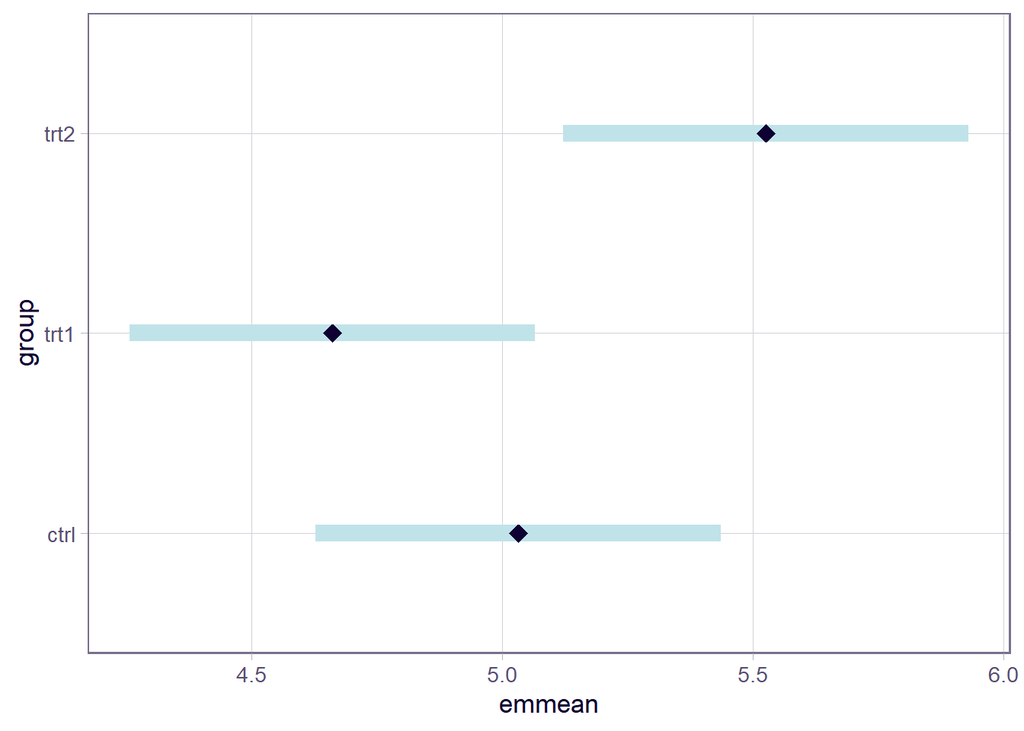

```r
# plot(emm)

# dấu mũi tên 2 chiều là không khác biệt
# hai dấu mũi tên ngược nhau là khác biệt
emmeans:::plot.emmGrid(emm,
                       comparisons = F)
```

# 6 ANOVA 1 yếu tố | Nonparametric | Không bắt cặp

## 6.1 Check assumption

### 6.1.1 Normality

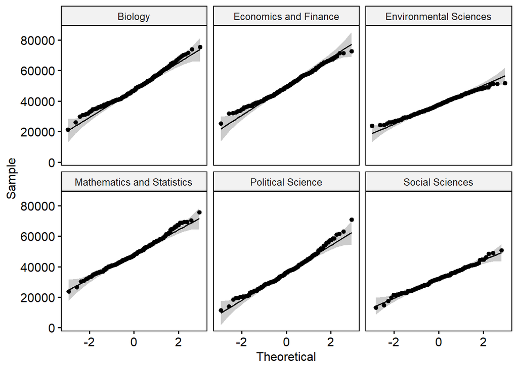

```r
library(ggplot2)
library(ggpubr)
df$major <- factor(df$major)
ggpubr:::ggqqplot(data = df,
                  x = "salary",
                  facet.by = "major")
```

```r
major_ok <- unique(df$major)

for(i in 1:length(major_ok)){
check_normality <- df |> subset(major == major_ok[i])

print(major_ok[i])
kq <- nortest:::ad.test(check_normality$salary)
print(kq)
}
```

```
[1] Economics and Finance
Levels: Biology Economics and Finance Environmental Sciences Mathematics and Statistics Political Science Social Sciences

    Anderson-Darling normality test

data:  check_normality$salary
A = 0.6, p-value = 0.1

[1] Environmental Sciences
Levels: Biology Economics and Finance Environmental Sciences Mathematics and Statistics Political Science Social Sciences

    Anderson-Darling normality test

data:  check_normality$salary
A = 0.4, p-value = 0.3

[1] Political Science
Levels: Biology Economics and Finance Environmental Sciences Mathematics and Statistics Political Science Social Sciences

    Anderson-Darling normality test

data:  check_normality$salary
A = 0.9, p-value = 0.03

[1] Mathematics and Statistics
Levels: Biology Economics and Finance Environmental Sciences Mathematics and Statistics Political Science Social Sciences

    Anderson-Darling normality test

data:  check_normality$salary
A = 0.8, p-value = 0.05

[1] Biology
Levels: Biology Economics and Finance Environmental Sciences Mathematics and Statistics Political Science Social Sciences

    Anderson-Darling normality test

data:  check_normality$salary
A = 1, p-value = 0.001

[1] Social Sciences
Levels: Biology Economics and Finance Environmental Sciences Mathematics and Statistics Political Science Social Sciences

    Anderson-Darling normality test

data:  check_normality$salary
A = 0.3, p-value = 0.6
```

```r
### Lưu ý nếu dữ liệu không đều nhau thì nên thực hiện thủ công trích từng vector kiểm riêng normality
df_wide <- df[ , c("major", "salary")] %>%
  group_by(major) %>%
  mutate(id = row_number()) %>%
  ungroup() %>% as.data.frame() %>%
  pivot_wider(
    names_from = major,
    values_from = salary
  )

df_wide <- df_wide[, -1]
library(MVN)
### Vì dữ liệu df_wide bị NA nên khi thực hiện, package sẽ tự động remove NA, làm sai kết quả.
df_wide <- na.omit(df_wide)
MVN:::mvn(df_wide)
```

```
$multivariate_normality
           Test Statistic p.value     Method      MVN
1 Henze-Zirkler      0.95    0.34 asymptotic ✓ Normal

$univariate_normality
              Test                   Variable Statistic p.value    Normality
1 Anderson-Darling      Economics and Finance      0.49   0.218     ✓ Normal
2 Anderson-Darling     Environmental Sciences      0.14   0.971     ✓ Normal
3 Anderson-Darling          Political Science      0.72   0.060     ✓ Normal
4 Anderson-Darling Mathematics and Statistics      0.62   0.102     ✓ Normal
5 Anderson-Darling                    Biology      0.90   0.021 ✗ Not normal
6 Anderson-Darling            Social Sciences      0.30   0.585     ✓ Normal

$descriptives
                    Variable   n  Mean Std.Dev Median   Min   Max  25th  75th  Skew Kurtosis
1      Economics and Finance 206 49760    8423  49349 25351 72787 43373 56022 0.209      2.8
2     Environmental Sciences 206 37229    5681  37132 23870 51332 33221 41368 0.031      2.6
3          Political Science 206 36876    9296  36514 11444 70932 30272 42177 0.480      3.7
4 Mathematics and Statistics 206 48594    8203  47554 23867 75597 43098 53688 0.328      3.3
5                    Biology 206 47462    8330  46567 25998 70095 41099 53279 0.279      2.7
6            Social Sciences 206 32044    6205  32032 13300 50705 27613 36021 0.078      3.3

$data
# A tibble: 206 × 6
   `Economics and Finance` `Environmental Sciences` `Political Science` `Mathematics and Statistics` Biology `Social Sciences`
                     <dbl>                    <dbl>               <dbl>                        <dbl>   <dbl>             <dbl>
 1                  45254.                   40553.              33969.                       35599.  49111.            28128.
 2                  50618.                   27007.              37392.                       39343.  51223.            23717.
 3                  42593.                   39704.              30087.                       36204.  49476.            35882.
 4                  60407.                   32519.              31494.                       58081.  46243.            37036.
 5                  35881.                   33069.              39451.                       56996.  39588.            39758.
 6                  51564.                   37804.              20511.                       41619.  64486.            21722.
 7                  43380.                   35192.              44028.                       41373.  45504.            33109.
 8                  71468.                   34191.              37810.                       65013.  39369.            31750.
 9                  51518.                   39038.              42065.                       64525.  35816.            31485.
10                  55664.                   43333.              30612.                       58671.  37626.            25659.
# ℹ 196 more rows

$subset
NULL

$outlierMethod
[1] "none"

attr(,"class")
[1] "mvn"
```

### 6.1.2 Variance homogeneity

```r
library(car)

car:::leveneTest(salary ~ major,
           data = df)
```

```
Levene's Test for Homogeneity of Variance (center = median)
        Df F value  Pr(>F)
group    5    16.3 9.6e-16 ***
      1747
---
Signif. codes:  0 '***' 0.001 '**' 0.01 '*' 0.05 '.' 0.1 ' ' 1
```

```r
stats:::bartlett.test(salary ~ major,
           data = df)
```

```
    Bartlett test of homogeneity of variances

data:  salary by major
Bartlett's K-squared = 108, df = 5, p-value <2e-16
```

## 6.2 Run ANOVA one-way Nonparametric

Assumptions cho parametric bị vi phạm nên ta áp dụng kiểm định nonparametric.

```r
fit1 <- stats:::kruskal.test(salary ~ major,
           data = df)

fit1
```

```
    Kruskal-Wallis rank sum test

data:  salary by major
Kruskal-Wallis chi-squared = 781, df = 5, p-value <2e-16
```

## 6.3 Effect size

```r
rstatix:::kruskal_effsize(salary ~ major,
                          data = df)
```

```
# A tibble: 1 × 5
  .y.        n effsize method  magnitude
* <chr>  <int>   <dbl> <chr>   <ord>
1 salary  1753   0.444 eta2[H] large
```

## 6.4 Post-hoc analysis | Multiple comparisons

### 6.4.1 Bonferroni

• “bonferroni” Kiểm soát family-wise error rate (FWER), khá bảo thủ • “holm” Kiểm soát FWER, thường ít bảo thủ hơn Bonferroni • “bh” Kiểm soát false discovery rate (FDR)

```r
library(FSA)
FSA:::dunnTest(salary ~ major,
               data = df,
               method = "bonferroni")
```

```
                                            Comparison      Z P.unadj   P.adj
1                      Biology - Economics and Finance  -2.14 3.2e-02 4.8e-01
2                     Biology - Environmental Sciences  13.68 1.4e-42 2.1e-41
3       Economics and Finance - Environmental Sciences  15.45 7.7e-54 1.2e-52
4                 Biology - Mathematics and Statistics  -0.86 3.9e-01 1.0e+00
5   Economics and Finance - Mathematics and Statistics   1.24 2.1e-01 1.0e+00
6  Environmental Sciences - Mathematics and Statistics -14.06 6.6e-45 9.9e-44
7                          Biology - Political Science  14.18 1.3e-45 1.9e-44
8            Economics and Finance - Political Science  15.88 9.3e-57 1.4e-55
9           Environmental Sciences - Political Science   1.12 2.6e-01 1.0e+00
10      Mathematics and Statistics - Political Science  14.55 6.1e-48 9.1e-47
11                           Biology - Social Sciences  18.07 5.9e-73 8.8e-72
12             Economics and Finance - Social Sciences  19.56 3.4e-85 5.0e-84
13            Environmental Sciences - Social Sciences   6.26 3.9e-10 5.9e-09
14        Mathematics and Statistics - Social Sciences  18.34 4.2e-75 6.2e-74
15                 Political Science - Social Sciences   5.07 4.0e-07 6.0e-06
```

## 6.5 Vẽ đồ thị

```r
library(ggstatsplot)
library(tidyverse)

set.seed(20)

kq <- ggstatsplot:::ggbetweenstats(data = df,
                     x = major,
                     y = salary,
                     var.equal = TRUE,
                     type = "nonparametric",
                     plot.type = "box",
                     pairwise.comparisons = T,
                     pairwise.display = "all",
                     p.adjust.method = "bonferroni",
                     # p.adjust.method = "none",
                     centrality.plotting = T,
                     centrality.path = T,
                     digits = 4L,
                     centrality.point.args = list(size = 4, color = "darkred"),
                     centrality.label.args = list(size = 4,
                                                  nudge_x = 0.4,
                                                  segment.linetype = 4),
                     ggtheme = theme_classic(base_size = 12),
                     bf.message = T,
                     results.subtitle = T,
                     caption = "",
                     ggsignif.args = list(size = 0.5,
                                          vjust = 0,
                                          step_increase = 0.1,
                                          textsize = 5),
                     point.args = list(position = ggplot2::position_jitterdodge(dodge.width = 0,                                                                 jitter.width = 0,                                                                jitter.height = 0),
                                       alpha = 0.5,
                                       size = 6,
                                       stroke = 0,
                                       na.rm = TRUE)
                     )

# kq

ggstatsplot:::extract_stats(kq)
```

```
$subtitle_data
# A tibble: 1 × 15
  parameter1 parameter2 statistic df.error   p.value method                       effectsize      estimate conf.level conf.low conf.high conf.method
  <chr>      <chr>          <dbl>    <int>     <dbl> <chr>                        <chr>              <dbl>      <dbl>    <dbl>     <dbl> <chr>
1 salary     major           781.        5 1.18e-166 Kruskal-Wallis rank sum test Epsilon2 (rank)    0.446       0.95    0.418         1 percentile bootstrap
  conf.iterations n.obs expression
            <int> <int> <list>
1             100  1753 <language>

$caption_data
NULL

$pairwise_comparisons_data
# A tibble: 15 × 9
   group1                     group2                     statistic  p.value alternative distribution p.adjust.method test  expression
   <chr>                      <chr>                          <dbl>    <dbl> <chr>       <chr>        <chr>           <chr> <list>
 1 Biology                    Economics and Finance          2.14  4.79e- 1 two.sided   z            Bonferroni      Dunn  <language>
 2 Biology                    Environmental Sciences        13.7   2.06e-41 two.sided   z            Bonferroni      Dunn  <language>
 3 Biology                    Mathematics and Statistics     0.857 1   e+ 0 two.sided   z            Bonferroni      Dunn  <language>
 4 Biology                    Political Science             14.2   1.92e-44 two.sided   z            Bonferroni      Dunn  <language>
 5 Biology                    Social Sciences               18.1   8.84e-72 two.sided   z            Bonferroni      Dunn  <language>
 6 Economics and Finance      Environmental Sciences        15.4   1.16e-52 two.sided   z            Bonferroni      Dunn  <language>
 7 Economics and Finance      Mathematics and Statistics     1.24  1   e+ 0 two.sided   z            Bonferroni      Dunn  <language>
 8 Economics and Finance      Political Science             15.9   1.39e-55 two.sided   z            Bonferroni      Dunn  <language>
 9 Economics and Finance      Social Sciences               19.6   5.03e-84 two.sided   z            Bonferroni      Dunn  <language>
10 Environmental Sciences     Mathematics and Statistics    14.1   9.92e-44 two.sided   z            Bonferroni      Dunn  <language>
11 Environmental Sciences     Political Science              1.12  1   e+ 0 two.sided   z            Bonferroni      Dunn  <language>
12 Environmental Sciences     Social Sciences                6.26  5.85e- 9 two.sided   z            Bonferroni      Dunn  <language>
13 Mathematics and Statistics Political Science             14.5   9.12e-47 two.sided   z            Bonferroni      Dunn  <language>
14 Mathematics and Statistics Social Sciences               18.3   6.23e-74 two.sided   z            Bonferroni      Dunn  <language>
15 Political Science          Social Sciences                5.07  6.05e- 6 two.sided   z            Bonferroni      Dunn  <language>

$descriptive_data
NULL

$one_sample_data
NULL

$tidy_data
NULL

$glance_data
NULL

attr(,"class")
[1] "ggstatsplot_stats" "list"
```

```r
ggsave(filename = "kq_dunn.png",
       plot = kq,
       width = 14,
       height = 10,
       units = "in",
       dpi = 300)
```

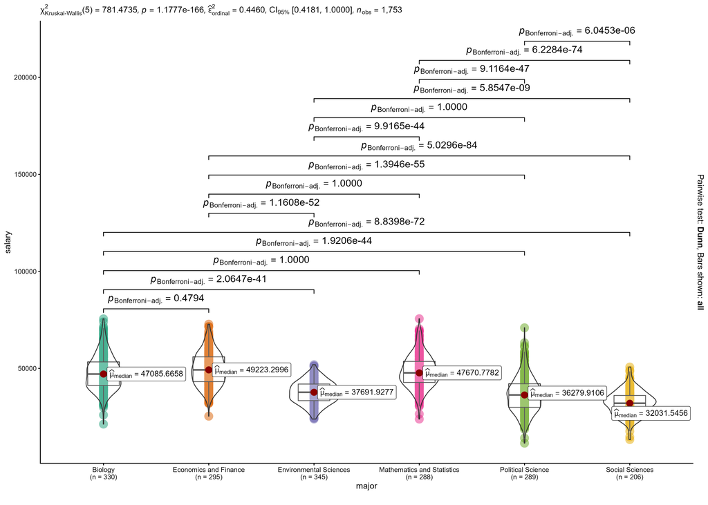

## 6.6 Summary giữa các nhóm

```r
library(DescTools)

DescTools:::MedianCI(upper_30)
```

```
median lwr.ci upr.ci
 43712  39356  51706
attr(,"conf.level")
[1] 0.97
```

```r
quantile(upper_30)
```

```
   0%   25%   50%   75%  100%
22191 36805 43712 54950 71595
```

```r
options(pillar.sigfig = 8)
df |> dplyr:::group_by(major) |>
  dplyr:::summarise(median = DescTools:::MedianCI(salary)[1],
                    lower = DescTools:::MedianCI(salary)[2],
                    upper = DescTools:::MedianCI(salary)[3],
                    Q2 = quantile(salary)[2],
                    Q4 = quantile(salary)[4],
                    IQR = IQR(salary))
```

```
# A tibble: 6 × 7
  major                         median     lower     upper        Q2        Q4        IQR
  <fct>                          <dbl>     <dbl>     <dbl>     <dbl>     <dbl>      <dbl>
1 Biology                    47085.666 45676.770 48969.948 41201.484 53332.147 12130.664
2 Economics and Finance      49223.300 47842.436 50416.159 43166.767 55939.829 12773.062
3 Environmental Sciences     37691.928 36750.087 38476.916 33365.419 41924.629  8559.2101
4 Mathematics and Statistics 47670.778 46306.616 49317.398 42758.735 53590.981 10832.246
5 Political Science          36279.911 34444.640 37529.564 29934.009 42064.680 12130.670
6 Social Sciences            32031.546 31325.999 33200.275 27612.823 36021.198  8408.3754
```

**Các trường hợp phân tích paired samples ghép cặp before-after hay theo dõi theo thời gian được mình trình bày chi tiết ở link này [[**Paired samples**]](https://thongkevavedothi.com/blog/xac-suat-va-thong-ke/paired_samples.html)**

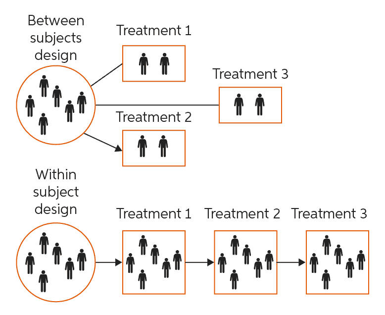